# Analysis of Kanye West Songs

Adam Ackerman

May 17, 2018

# Introduction:

Have you ever wondered about how Kanye West became so successful in the rap genre and subsequently the musical genius of our generation? This tutorial will explore the reasons for Kanye’s success through data analysis and examine the challenge of predicting whether or not a Kanye song is explicit or not based on factors beyond the presence of swear words.

# Getting the Data:

To obtain the data for our assessment of Kanye, we have to gather the data from Spotify and tidy it for our analysis. Spotify does not make this easy so there will be several steps interacting with the Spotify API to get all of the data we need. [Here](https://beta.developer.spotify.com/documentation/web-api/reference/) is a link to the Spotify API and the endpoints you can reach, of which we wil use several. To replicate this, you will need a Spotify API authorization key, which you can grab with a Spotify account and clicking the getToken button at the following [link](https://beta.developer.spotify.com/console/get-several-tracks/)

The first step is to get the album IDs of the albums by Kanye that we want to get song data from. To do this we can use the httr library for http requests in combination with the jsonlite package to convert the json data into a data frame with ease. We need to request from the Spotify API endpoint for albums, using Yeezy’s official Spotify code which is 5K4W6rqBFWDnAN6FQUkS6x. I decided to limit it to 11 because Ye has a lot of albums and I want to focus on the more popular and recent albums but you may change it to whatever you want with the limit=# part of the http request.

```r
library("httr")
library("jsonlite")

#Insert your key after "Bearer ", the key I used is there as an example (it wont work if you try to use my same key)
key <- 'Bearer BQA5DmUHeWMnooH3bU85--t-I9XRVkfWfKZu8r7qRBFvrf6A7YQ-azcbaJvkTxvZ8Ezo8FbWdjv6cB8yO63LC3sYoLkq1pHA_l4REOS-1cjUSoOCRuXNTd19Z0k9HQwAfBTHiCFk5U0KPz8'

album_data <- httr::GET('https://api.spotify.com/v1/artists/5K4W6rqBFWDnAN6FQUkS6x/albums?limit=11',
      accept_json(),
      add_headers('Authorization' = key))

jsondata <- fromJSON(txt=content(album_data, as="text"))
```

This data frame contains a lot of data frames within it and other complex structures that don’t display output well. However, what we want to get from this is the album ids, seen here:

```r
ids <- jsondata$items$id
ids
```

```
##  [1] "7gsWAHLeT0w7es6FofOXk1" "7D2NdGvBHIavgLhmcwhluK"
##  [3] "20r762YmB5HeofjMCiPMLv" "6klUp8sQyRXGuJhqZu4PG3"
##  [5] "3WFTGIO6E3Xh4paEOBY9OU" "3SZr5Pco2oqKFORCP3WNj9"
##  [7] "7nxBMFwJtTTKDNxVCKmYi3" "5ll74bqtkcXlKE7wwkMq4g"
##  [9] "4yJqrqT2BpuXLj5BMJlAXR" "3ff2p3LnR6V7m6BinwhNaQ"
## [11] "0bSrRp502dZKkpwZa9F1MY"
```

With all of the album IDs, we can work on getting all of the song data we need. To do this, we have to call the api endpoint for audio features on each song of each album, collapsing all of this into one data frame. First, we hit the album/{id}/tracks endpoint to get the song ids for all of the songs on the album we are getting data for. Then we hit the audio-features endpoint giving it all the ids of the songs on the album that we just got. My method for collapsing all of this data is to get the song audio features as a separate data frame each time, then add that data frame to a list, in this case audio_df_list. We will see the merging of all the data frames in the next part. I can’t show you what the intermediate data frames look like since this is all in a loop but feel free to add print statements or try out the api calls with one id to see what the data looks like at each step.

```r
library("tidyverse")

audio_df_list <- c()
i <- 0

for (id in ids) {
  #Getting the track data for each song on the album, we really want the track id for each song
  track_data <- httr::GET(paste('https://api.spotify.com/v1/albums/', id, '/tracks', sep=""),
      accept_json(),
      add_headers('Authorization' = key))

  track_data <- fromJSON(txt=content(track_data, as="text"))

  #Get the track ids as a string that meets the format for requesting multiple ids on Spotify
  track_ids <- paste(track_data$items$id, collapse="%2C")
  #Get the track name to combine with the audio features
  track_names <- track_data$items$name

  #Get the audio data for all the songs on the album, this has many attributes which I talk about in the next section
  audio_data <- httr::GET(paste('https://api.spotify.com/v1/audio-features?ids=', track_ids, sep=""),
      accept_json(),
      add_headers('Authorization' = key))


  audio_data <- fromJSON(txt=content(audio_data, as="text"))

  #add songnames to the audio data
  audio_data$audio_features$songtitle <- track_names

  #Get the track data for the song, this includes 2 pieces of info we need which are explicit and popularity of the song
  song_data <- httr::GET(paste('https://api.spotify.com/v1/tracks?ids=', track_ids, sep=""),
      accept_json(),
      add_headers('Authorization' = key))

  song_data <- fromJSON(txt=content(song_data, as="text"))

  audio_data$audio_features$explicit <- song_data$tracks$explicit
  audio_data$audio_features$popularity <- song_data$tracks$popularity

  #add to list
  audio_df_list[i] <- audio_data
  i <- i + 1

}
```

To get our final desired one data frame, we just need to merge everything. Using the reduce function we can merge each data frame from the list all in one call leading to the final data frame. I suggest looking at the Spotify documentation to understand what these metrics mean, found [here](https://beta.developer.spotify.com/documentation/web-api/reference/tracks/get-several-audio-features/)

```r
all_audio <- Reduce(function(x, y) merge(x,y,all=TRUE), audio_df_list)
as_tibble(all_audio)
```

```
## # A tibble: 154 x 21
##    danceability energy   key loudness  mode speechiness acousticness
##           <dbl>  <dbl> <int>    <dbl> <int>       <dbl>        <dbl>
##  1        0.228  0.861    11   - 3.60     0      0.125       0.0113
##  2        0.235  0.273     6   -11.3      1      0.0290      0.721
##  3        0.236  0.115    10   -16.5      0      0.0349      0.912
##  4        0.289  0.283    10   -13.2      0      0.0483      0.949
##  5        0.291  0.874    11   - 3.27     0      0.0909      0.0125
##  6        0.304  0.756    11   - 4.86     1      0.135       0.0162
##  7        0.328  0.273     6   -11.2      1      0.0287      0.701
##  8        0.336  0.683     6   - 6.82     0      0.151       0.00735
##  9        0.359  0.662     1   - 2.84     1      0.0466      0.134
## 10        0.362  0.602     5   - 6.09     0      0.0681      0.0136
## # ... with 144 more rows, and 14 more variables: instrumentalness <dbl>,
## #   liveness <dbl>, valence <dbl>, tempo <dbl>, type <chr>, id <chr>,
## #   uri <chr>, track_href <chr>, analysis_url <chr>, duration_ms <int>,
## #   time_signature <int>, songtitle <chr>, explicit <lgl>,
## #   popularity <int>
```

Looking at the data, there isn’t a lot of problems with it. The only missing data appears to be some tracks that have 0 popularity (lowest possible score) and are from some strange songs (skit #3, what is that Kanye?). Since there are only a very small number of these we can just filter them out by ensuring popularity is greater than 0.

```r
all_audio <- all_audio %>% filter(popularity > 0)
```

# Exploratory Data Analysis

Now its finally time to do some exploratory data analysis! Lets take a look at some features of the dataset, specifically some data that might help answer the question of the differences between explicit and non explicit songs. Here is the energy column as the x coordinate plotted against the popularity of the song, with the color showing whether or not the song is explicit.

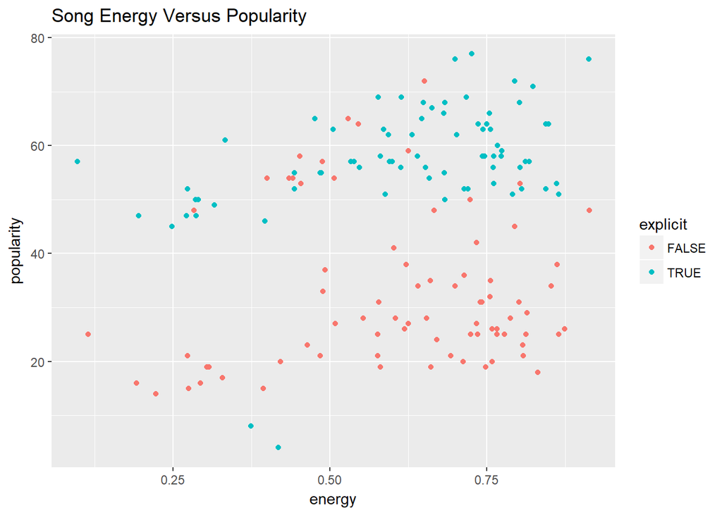

```r
all_audio %>% ggplot(mapping=aes(x = energy, y = popularity, color=explicit)) + geom_point() + ggtitle("Song Energy Versus Popularity")
```

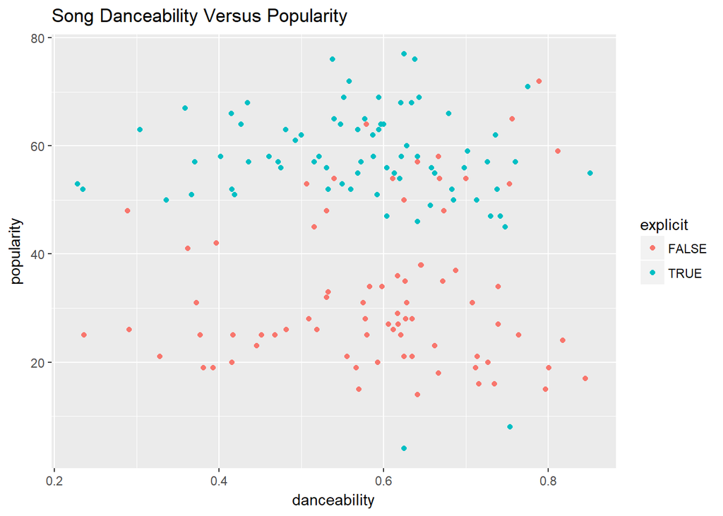

```r
all_audio %>% ggplot(mapping=aes(x = danceability, y = popularity, color=explicit)) + geom_point() + ggtitle("Song Danceability Versus Popularity")
```

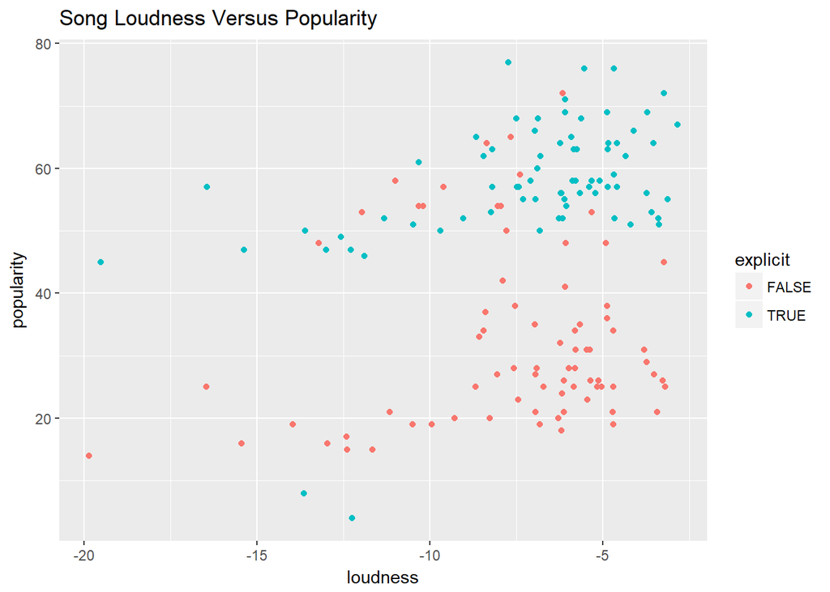

```r
all_audio %>% ggplot(mapping=aes(x = loudness, y = popularity, color=explicit)) + geom_point() + ggtitle("Song Loudness Versus Popularity")
```

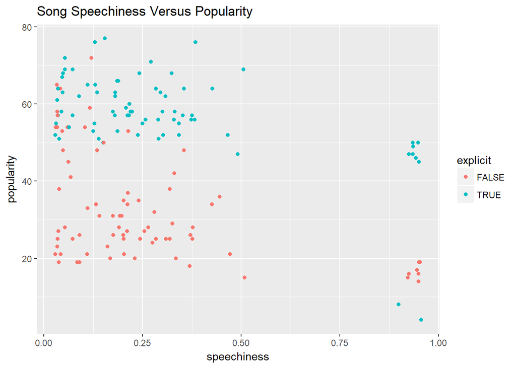

```r
all_audio %>% ggplot(mapping=aes(x = speechiness, y = popularity, color=explicit)) + geom_point() + ggtitle("Song Speechiness Versus Popularity")
```

There is definitely a repeating clustering between all of these variables and popularity for explicit and non explicit songs. I suspect explicit songs are overall much more popular than non explicit ones but lets make a graph to confirm.

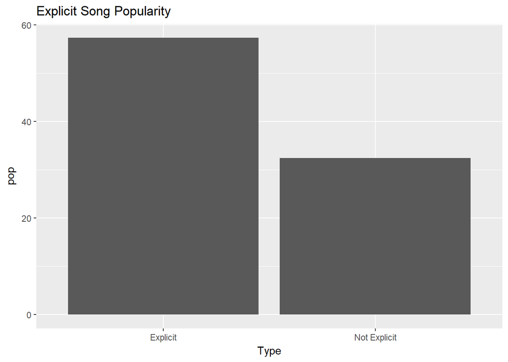

```r
all_audio %>%  mutate(Type = ifelse(explicit, "Explicit", "Not Explicit")) %>% group_by(Type) %>% summarize(pop=mean(popularity)) %>% ggplot(mapping=aes(x=Type, y=pop)) + geom_bar(stat="identity") + ggtitle("Explicit Song Popularity")
```

Explicit songs have a way larger average in poularity for sure. The fact that all of the 4 scatterplots have groups associated with explicit versus non explicit songs suggests that a model that detects clusters and predicts appropriately might be a good prediction model. This leads us to the k nearest neighbors model.

# Prediction

Since in the Exploratory Data Analysis we saw explicit songs had a very different popularity value compared to non explicit songs, lets explore the difference between a k nearest neighbors model that does include popularity as a feature and a k nearest neighbors model that does not.

First we should select the features we want to use, in addition to songtitle for sampling the dataset to make test and training data.

```r
set.seed(1000)

audio_feats <- all_audio %>% select(energy, danceability, loudness, popularity, songtitle, explicit)

testdata <- audio_feats %>%
  sample_frac(.2)

traindata <- audio_feats %>%
  anti_join(testdata, by="songtitle")
```

With the training and testing data built, its time to make to kNN models. We want to use all available features, the test and training data, k=5, and set norm = TRUE so that the data will be normalized for the model. For the first we include popularity and the second we do not.

```r
tk <- kNN(explicit~., traindata %>% select(-songtitle), testdata %>% select(-songtitle), norm=TRUE, k=5)
nopop <- kNN(explicit~., traindata %>% select(-songtitle, -popularity), testdata %>% select(-songtitle, -popularity), norm=TRUE, k=5)
```

Lets look at the performance table, showing the predictions versus the actual labels (explicit vs not explicit)

```r
table(testdata[,'explicit'],tk) %>% knitr::kable()
```

|  | FALSE | TRUE |
| --- | --- | --- |
| FALSE | 14 | 4 |
| TRUE | 1 | 11 |

```r
table(testdata[,'explicit'], nopop) %>% knitr::kable()
```

|  | FALSE | TRUE |
| --- | --- | --- |
| FALSE | 11 | 7 |
| TRUE | 6 | 6 |

These preliminary results show a very successful predictor with popularity included but a not so much successful classifier that excludes it. Lets follow up with a more intense verification procedure of cross validating the 2 models.

# Cross Validation

To start we will assume a null hypothesis of there being no significant difference in the performance of the two models. To perform a 5 fold cross validation experiment we need to use the cvTools package to easily select the test and train data for each fold. Then we go ahead and build predictions using each model, calculate the error rate, and combine the error rate for both models into a data frame each fold. (test modeled from [here](http://www.hcbravo.org/IntroDataSci/bookdown-notes/model-selection.html#k-fold-cross-validation))

```r
library(cvTools)
set.seed(1111)
fold_indices <- cvFolds(n=nrow(audio_feats), K=5)

error_rates <- sapply(1:5, function(fold_index) {
  #get indices for test set for current fold
  test_indices <- which(fold_indices$which == fold_index)

  test_set <- na.omit(audio_feats[test_indices,])
  train_set <- na.omit(audio_feats[-test_indices,])

  #build models
  pop_fit <- kNN(explicit~., train_set %>% select(-songtitle), test_set %>% select(-songtitle), norm=TRUE, k=5)
  nopop_fit <- kNN(explicit~., train_set %>% select(-songtitle, -popularity), test_set %>% select(-songtitle, -popularity), norm=TRUE, k=5)

  #calculate error
  pop_error <- mean(test_set$explicit != pop_fit)
  nopop_error <- mean(test_set$explicit != nopop_fit)


  c(pop_error, nopop_error)
  })
rownames(error_rates) <- c("Popularity", "No Popularity")
error_rates <- as.data.frame(t(error_rates))
```

Lets look at a plot of the error rates for each fold for the 2 different models

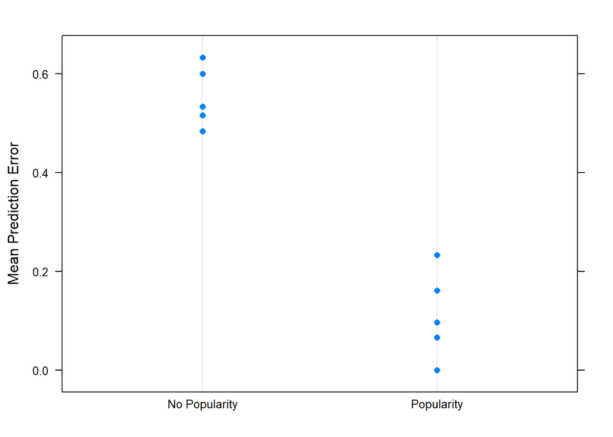

```r
error_rates <- error_rates %>%
  mutate(fold=1:n()) %>%
  gather(method,error,-fold)


dotplot(error~method, data=error_rates, ylab="Mean Prediction Error")
```

The last step for us is to check whether there is a significant difference in the two models. If our p value for the relationship between error and the method used is less than an alpha level of .05, we can reject the null hypothesis that the two models are not different (more on p testing [here](http://blog.minitab.com/blog/michelle-paret/alphas-p-values-confidence-intervals-oh-my))

```r
lm(error~method, data=error_rates) %>%
  broom::tidy() %>%
  knitr::kable()
```

| term | estimate | std.error | statistic | p.value |
| --- | --- | --- | --- | --- |
| (Intercept) | 0.5533333 | 0.0343396 | 16.113541 | 2.00e-07 |
| methodPopularity | -0.4417204 | 0.0485636 | -9.095711 | 1.71e-05 |

The p value is very small, which is far under the alpha level. This means we can reject the null hypothesis that there is no difference between the two models. This makes sense as the popularity one performed really well in comparison to the one without popularity.

So it seems explicit songs are more popular, but how come? Taking a look at the differences between explicit and non explicit Kanye songs on the other features does not reveal any major disparity like there was with the popularity feature.

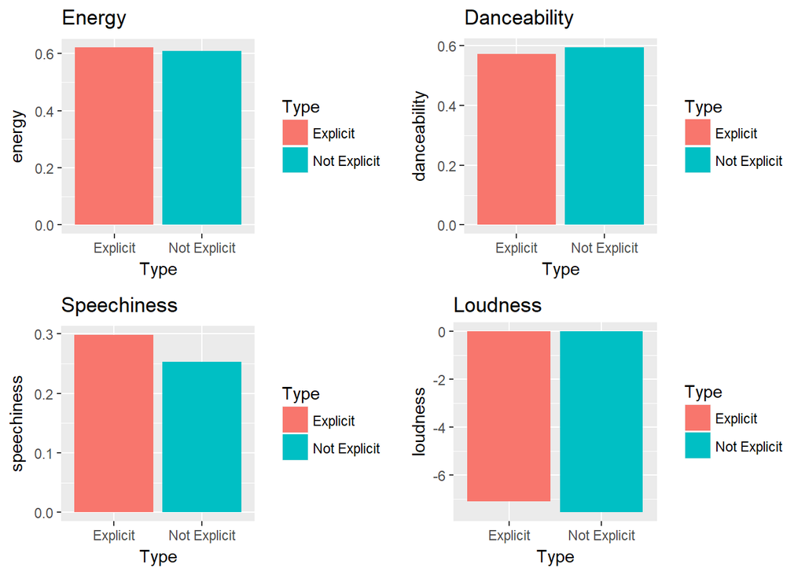

```r
library("ggpubr")
g1 <- all_audio %>% mutate(Type = ifelse(explicit, "Explicit", "Not Explicit")) %>% group_by(Type) %>% summarize(energy=mean(energy))  %>% ggplot(mapping=aes(x=Type, y=energy, fill=Type)) + geom_bar(stat="identity")  + ggtitle("Energy")


g2 <- all_audio %>% mutate(Type = ifelse(explicit, "Explicit", "Not Explicit")) %>% group_by(Type) %>% summarize(danceability=mean(danceability)) %>% ggplot(mapping=aes(x=Type, y=danceability, fill=Type)) + geom_bar(stat="identity") + ggtitle("Danceability")

g3 <- all_audio %>%  mutate(Type = ifelse(explicit, "Explicit", "Not Explicit")) %>% group_by(Type) %>%  summarize(speechiness=mean(speechiness)) %>% ggplot(mapping=aes(x=Type, y=speechiness, fill=Type)) + geom_bar(stat="identity") + ggtitle("Speechiness")

g4 <- all_audio %>%  mutate(Type = ifelse(explicit, "Explicit", "Not Explicit")) %>% group_by(Type) %>% summarize(loudness=mean(loudness)) %>% ggplot(mapping=aes(x=Type, y=loudness, fill=Type)) + geom_bar(stat="identity") + ggtitle("Loudness")

ggarrange(g1, g2, g3, g4,
          ncol = 2, nrow = 2)
```

Maybe there could be a factor I didn’t use that shows more of a difference between explicit and non explicit songs (that sounds like a fun thing to try to get to the bottom of after you finish this tutorial). Maybe the swear words are the only real reason that makes the songs popular. Maybe Kanye might know himself and is keeping his formula for success under wraps (pun intended). Regardless, this exercise is an example of the ways data science can be powerful in analyzing song data through methods like the K nearest neighbor algorithm.

If you liked this tutorial or have any suggestions please let me know! And of course shout out to Spotify for making this awesome data available and the legendary Yeezy himself for making all of this data in song form.